# Statistical Programming in R: Lecture 9

Factors

Josemari Feliciano

Fall 2024 - November 12

## Note

This is a converted long version of the Lecture 9 slides.

## Administrative: Final Project and Exam

Detailed information about both were shared last lecture.

1. Final project presentation: you will present your analysis during our December 3rd class. Under Week 8 on Canvas, there is a detailed document titled **Final Project Presentation Expectations.doc** which lists my clear expectation for your presentation materials. **Note to non-presenters:** I reserve the right to include one to two final exam questions on any material or insight presented by your peers.
2. Per the official Final Exam Schedule Calendar for Fall 2024, our final exam will be held on Tuesday, Dec 10, 2024 at 05:30 PM - 08:00PM. It will be cumulative. Same format: open book, you may take the exam anywhere. Exam will be written so that it can completed and submitted by most of you within the first 90-100 mins like the first midterm. I’ll be in the classroom if you want to take it in person which will allow you to ask clarifying questions.

## Administrative: Final Project

Example of professional presentation slides from a 5-min recorded talk I gave in 2020: https://www.youtube.com/watch?v=An8GjcWOTKQ

Again, closely follow the **Final Project Presentation Expectations.doc** under Week 8 on Canvas.

## Other Administrative Items

1. Per university policy: November 26th (Tuesday): “Tuesday classes cancelled; Friday classes meet”
2. Homework 8 was posted last night. Due November 22nd (Friday) at 11:59 pm.
3. Later this week, Homework 9 will be posted. Due December 2nd (Monday) at 11:59 pm.

# Today’s agenda

Chapter 6: Factors using forcats (a core-tidyverse package)

Focuses on: (1) creating factor variables using factor(), (2) ordering data visualization based on numeric values ordering, (3) factor recoding, (4) lumping uncommon groups into ‘Other’.

```r
# load tidyverse before continuing
library(tidyverse)
```

## Factors

Factors are used for categorical variables.

Factors are useful when you want to display categorical variables using ordering that is not based on alphabetical order.

## Example

An example where it would be nice to order months based on a specific ordering not based on alphabetical order:

```r
monthly_sales <- read_csv("https://raw.githubusercontent.com/jmtfeliciano/teachingdata/refs/heads/main/monthly_sales.csv")

monthly_sales |>
  arrange(month)
```

```
## # A tibble: 12 × 2
##    month        sales
##    <chr>        <dbl>
##  1 April     1107535.
##  2 August     935907.
##  3 December  1030058.
##  4 February   896802.
##  5 January    999424.
##  6 July       937372.
##  7 June       967210.
##  8 March     1010861.
##  9 May       1000537.
## 10 November   962693.
## 11 October   1090660.
## 12 September 1058530.
```

Currently, month is of character type and when you arrange this data by month, the ordering–which is based on alphabetical order–doesn’t make sense in reality.

## Converting variable into factor type

When your categorical variable (in this case, character/string) has an inherent order not based on alphabetical order, it is best you convert them into factor type to help enforce the ordering for printing data and in your data visualizations. You are able to indicate the proper order by specifying the **levels** of your data. For data visualization, the default ordering for character (strings) type is alphabetical order.

## How to convert variable(s) into factor type

**Step 1:** Create a vector with the correct ordering or **levels**:

```r
level_vector <- c("January", "February", "March", "April", "May", "June",
                  "July", "August", "September", "October", "November", "December")
```

## How to convert variable(s) into factor type

**Step 2:** Override variable by using mutate() and factor():

```r
# levels or vector with the correct ordering
level_vector <- c("January", "February", "March", "April", "May", "June",
                  "July", "August", "September", "October", "November", "December")

# How to use factor:
# factor(variable_to_convert, levels = appropriate_levels)
monthly_sales_v2 <- monthly_sales |>
  mutate(month = factor(month, levels = level_vector))
```

One thing to note: month is no longer “char” (string). What variable type is now printed under month below?

```r
# After converting month into factor, this should print the desired output:
monthly_sales_v2 |>
  arrange(month)
```

```
## # A tibble: 12 × 2
##    month        sales
##    <fct>        <dbl>
##  1 January    999424.
##  2 February   896802.
##  3 March     1010861.
##  4 April     1107535.
##  5 May       1000537.
##  6 June       967210.
##  7 July       937372.
##  8 August     935907.
##  9 September 1058530.
## 10 October   1090660.
## 11 November   962693.
## 12 December  1030058.
```

## Let us work with the General Social Survey

The General Social Survey data is a built-in tidyverse data. Documentation for the data can be accessed via: https://forcats.tidyverse.org/reference/gss_cat.html

Before moving forward, let us load gss_cat into our R environment by running the script below:

```r
data("gss_cat")
head(gss_cat)
```

```
## # A tibble: 6 × 9
##    year marital         age race  rincome        partyid     relig denom tvhours
##   <int> <fct>         <int> <fct> <fct>          <fct>       <fct> <fct>   <int>
## 1  2000 Never married    26 White $8000 to 9999  Ind,near r… Prot… Sout…      12
## 2  2000 Divorced         48 White $8000 to 9999  Not str re… Prot… Bapt…      NA
## 3  2000 Widowed          67 White Not applicable Independent Prot… No d…       2
## 4  2000 Never married    39 White Not applicable Ind,near r… Orth… Not …       4
## 5  2000 Divorced         25 White Not applicable Not str de… None  Not …       1
## 6  2000 Married          25 White $20000 - 24999 Strong dem… Prot… Sout…      NA
```

### Sample data

| year | marital | age | race | rincome | partyid | relig | denom | tvhours |
| --- | --- | --- | --- | --- | --- | --- | --- | --- |
| 2000 | Never married | 26 | White | $8000 to 9999 | Ind,near rep | Protestant | Southern baptist | 12 |
| 2000 | Divorced | 48 | White | $8000 to 9999 | Not str republican | Protestant | Baptist-dk which |  |
| 2000 | Widowed | 67 | White | Not applicable | Independent | Protestant | No denomination | 2 |
| 2000 | Never married | 39 | White | Not applicable | Ind,near rep | Orthodox-christian | Not applicable | 4 |
| 2000 | Divorced | 25 | White | Not applicable | Not str democrat | None | Not applicable | 1 |

## Summarizing data and creating data visualization

Suppose we are to calculate the average tv hours watched by religious group:

```r
religion_tv_summary <- gss_cat |>
  group_by(relig) |>
  summarize(
    mean_tv_hours = mean(tvhours, na.rm = TRUE), n = n()
  )
religion_tv_summary
```

```
## # A tibble: 15 × 3
##    relig                   mean_tv_hours     n
##    <fct>                           <dbl> <int>
##  1 No answer                        2.72    93
##  2 Don't know                       4.62    15
##  3 Inter-nondenominational          2.87   109
##  4 Native american                  3.46    23
##  5 Christian                        2.79   689
##  6 Orthodox-christian               2.42    95
##  7 Moslem/islam                     2.44   104
##  8 Other eastern                    1.67    32
##  9 Hinduism                         1.89    71
## 10 Buddhism                         2.38   147
## 11 Other                            2.73   224
## 12 None                             2.71  3523
## 13 Jewish                           2.52   388
## 14 Catholic                         2.96  5124
## 15 Protestant                       3.15 10846
```

### Creating data visualization: hours TV watched per religion

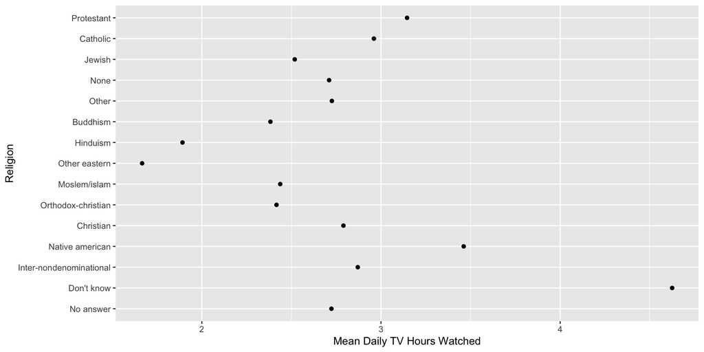

```r
ggplot(data = religion_tv_summary,
       mapping = aes(x = mean_tv_hours, y = relig)) +
  geom_point() +
  labs(x = "Mean Daily TV Hours Watched", y = "Religion")
```

## Modify factor order in data visualization only

Suppose we are not happy with the last data visualization.

Instead of using the religion order given to us, suppose we want to modify the graph so that the order or levels are from most to least hours.

To do this, we can use `fct_reorder(categorical_variable, numeric_variable_to_order_by)`.

Instead of `y = relig`, let us set `y = fct_reorder(relig, mean_tv_hours)`.

## Modify factor order in data visualization only

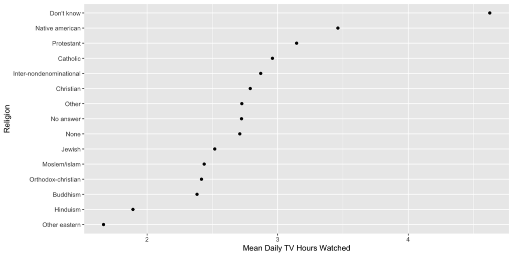

```r
ggplot(data = religion_tv_summary,
       mapping = aes(x = mean_tv_hours, y = fct_reorder(relig, mean_tv_hours))) +
  geom_point() +
  labs(x = "Mean Daily TV Hours Watched", y = "Religion")
```

## Let us worth with flights data again

Let us work with flights data. For documentation, the data can be found here: https://www.rdocumentation.org/packages/nycflights13/versions/1.0.1/topics/flights

```r
flights <- read_rds("https://github.com/jmtfeliciano/teachingdata/raw/refs/heads/main/flights.rds")
head(flights)
```

```
## # A tibble: 6 × 19
##    year month   day dep_time sched_dep_time dep_delay arr_time sched_arr_time
##   <int> <int> <int>    <int>          <int>     <dbl>    <int>          <int>
## 1  2013     1    10     1649           1655        -6     1958           2029
## 2  2013     5    16     1257           1305        -8     1436           1455
## 3  2013    11    11     1821           1825        -4     2108           2149
## 4  2013     4    24      918            925        -7     1238           1235
## 5  2013    11    20     1724           1729        -5     1923           1941
## 6  2013     9    11      814            815        -1     1041           1105
## # ℹ 11 more variables: arr_delay <dbl>, carrier <chr>, flight <int>,
## #   tailnum <chr>, origin <chr>, dest <chr>, air_time <dbl>, distance <dbl>,
## #   hour <dbl>, minute <dbl>, time_hour <dttm>
```

## Factor Recoding

Step 1: If variable is not a factor already, convert it first into factor type using factor().

Step 2: Use `fct_recode(`variable, {recoding map: new value = old value}`)`.

```r
flights_v2 <- flights |>
  mutate(month = factor(month)) |>
  mutate(month = fct_recode(month,
                            "January" = "1",
                            "February" = "2",
                            "March" = "3",
                            "April" = "4",
                            "May" = "5",
                            "June" = "6",
                            "July" = "7",
                            "August" = "8",
                            "September" = "9",
                            "October" = "10",
                            "November" = "11",
                            "December" = "12"
                            ))
```

## Data after factor recoding

```r
flights_v2
```

```
## # A tibble: 180,000 × 19
##     year month     day dep_time sched_dep_time dep_delay arr_time sched_arr_time
##    <int> <fct>   <int>    <int>          <int>     <dbl>    <int>          <int>
##  1  2013 January    10     1649           1655        -6     1958           2029
##  2  2013 May        16     1257           1305        -8     1436           1455
##  3  2013 Novemb…    11     1821           1825        -4     2108           2149
##  4  2013 April      24      918            925        -7     1238           1235
##  5  2013 Novemb…    20     1724           1729        -5     1923           1941
##  6  2013 Septem…    11      814            815        -1     1041           1105
##  7  2013 Septem…    26     1654           1655        -1     1837           1845
##  8  2013 Decemb…    19     1206           1130        36     1414           1342
##  9  2013 Februa…    19     1946           1900        46     2209           2133
## 10  2013 April      14     1547           1445        62     1854           1750
## # ℹ 179,990 more rows
## # ℹ 11 more variables: arr_delay <dbl>, carrier <chr>, flight <int>,
## #   tailnum <chr>, origin <chr>, dest <chr>, air_time <dbl>, distance <dbl>,
## #   hour <dbl>, minute <dbl>, time_hour <dttm>
```

## Starwars Data Species

Remember, there is a built-in starwars data within the tidyverse package. Let us load this data into the R environment:

```r
data("starwars")
head(starwars)
```

```
## # A tibble: 6 × 14
##   name      height  mass hair_color skin_color eye_color birth_year sex   gender
##   <chr>      <int> <dbl> <chr>      <chr>      <chr>          <dbl> <chr> <chr>
## 1 Luke Sky…    172    77 blond      fair       blue            19   male  mascu…
## 2 C-3PO        167    75 <NA>       gold       yellow         112   none  mascu…
## 3 R2-D2         96    32 <NA>       white, bl… red             33   none  mascu…
## 4 Darth Va…    202   136 none       white      yellow          41.9 male  mascu…
## 5 Leia Org…    150    49 brown      light      brown           19   fema… femin…
## 6 Owen Lars    178   120 brown, gr… light      blue            52   male  mascu…
## # ℹ 5 more variables: homeworld <chr>, species <chr>, films <list>,
## #   vehicles <list>, starships <list>
```

## Starwars Data Species

```r
starwars |>
  count(species) |>
  arrange(desc(n))
```

```
## # A tibble: 38 × 2
##    species      n
##    <chr>    <int>
##  1 Human       35
##  2 Droid        6
##  3 <NA>         4
##  4 Gungan       3
##  5 Kaminoan     2
##  6 Mirialan     2
##  7 Twi'lek      2
##  8 Wookiee      2
##  9 Zabrak       2
## 10 Aleena       1
## # ℹ 28 more rows
```

## Lumping uncommon groupings into “Other”

`fct_lump_min(variable, number_cut_off)` allows us to reclassify groupings for uncommon factors or groupings as “Other” based on a numeric threshold or cut off.

For example, using `fct_lump_min(species, 2)` would only keep species designation if species count is 2 or more. In other words, species only appearing once is reclassified into “Other”.

```r
starwars_v2 <- starwars |>
  mutate(species = fct_lump_min(species, 2))

head(starwars)
```

```
## # A tibble: 6 × 14
##   name      height  mass hair_color skin_color eye_color birth_year sex   gender
##   <chr>      <int> <dbl> <chr>      <chr>      <chr>          <dbl> <chr> <chr>
## 1 Luke Sky…    172    77 blond      fair       blue            19   male  mascu…
## 2 C-3PO        167    75 <NA>       gold       yellow         112   none  mascu…
## 3 R2-D2         96    32 <NA>       white, bl… red             33   none  mascu…
## 4 Darth Va…    202   136 none       white      yellow          41.9 male  mascu…
## 5 Leia Org…    150    49 brown      light      brown           19   fema… femin…
## 6 Owen Lars    178   120 brown, gr… light      blue            52   male  mascu…
## # ℹ 5 more variables: homeworld <chr>, species <chr>, films <list>,
## #   vehicles <list>, starships <list>
```

Let us rerun count() code earlier:

```r
starwars_v2 |>
  count(species) |>
  arrange(desc(n))
```

```
## # A tibble: 10 × 2
##    species      n
##    <fct>    <int>
##  1 Human       35
##  2 Other       29
##  3 Droid        6
##  4 <NA>         4
##  5 Gungan       3
##  6 Kaminoan     2
##  7 Mirialan     2
##  8 Twi'lek      2
##  9 Wookiee      2
## 10 Zabrak       2
```

## Download Exercise9.qmd from Canvas and open in R. You have 25 mins to complete this. Then I will go over the solution.